# Topic Modeling in Python

## 1. Introduction

This tutorial is an introduction to Topic Modelling in Python. It presents the basic concepts and algorithms for extracting relevant topics from text documents.

Throughout this tutorial you will be presented with the concepts first, and then code examples and excercises in Jupyter Notebook format will follow.

### Learning objectives

Upon completion of this tutorial you will be able to:

1. Describe and demonstrate the computational and algorithmic characteristics of Topic Models
2. Design, and correctly implement Topic Models for specific scenarios and languages in Python
3. Analyze and compare Topic Model results
4. Optimize Topic Models and design effective algorithmic strategies to improve their accuracy
5. Communicate and describe the concepts and algorithmic properties behind text summarization
6. Apply Topic Models for text summarization

### Probabilistic Topic Modelling

Topic Modelling, or Probabilistic Topic Modelling (PTM), is a class of machine learning techniques used to discover the underlying topics in a text document or collection of documents.

The basic assumption behind PTM is that a document can be represented by a set of latent topics, multinomial distributions over words. Each document has then a set of topics and probability distributions associated with it. At the same time, each topic has a set of words and their probabilites of occurrence given that document and topic.

In the image below we can see how a document can be represented by 4 topics: "Arts", "Budgets", "Children", "Education". Each topic is an abstract collection of the words occurring in a document.

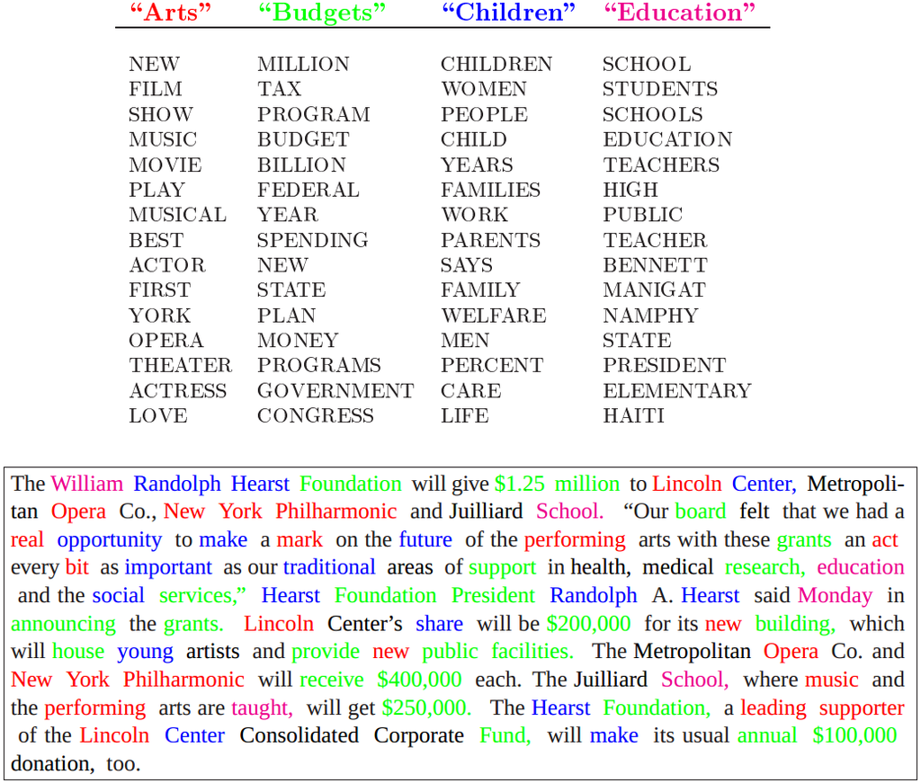

*(image source: Prof. Matthias Grossglauser Laboratory)*

### LDA

Latent Dirichlet Allocation (LDA) is a type of unsupervised machine learning algorithm that views documents as bags of words (collection of words per document with no regard to word order). LDA assumes a document is generated by picking a set of topics and then for each topic it picks a set of words. So LDA is able to infer the topics in a collection of documents by reverse engineering this assumption in the following way:

1. Given a *k* number of topics
2. Distribute these k topics across document *m* following a Dirichlet distribution, and assign each word a topic.
3. For each word *w* in document *m* , assign word *w* a topic

More formally:

1. Choose N ∼ Poisson(ξ).
2. Choose θ ∼ Dir(α).
3. For each of the N words wn:

   a. Choose a topic zn ∼ Multinomial(θ).

   b. Choose a word wn from p(wn |zn,β), a multinomial probability conditioned on the topic zn.

In the image below we demonstrate the bag of words approach. Each document collection is represented as a matrix of word occurrences.

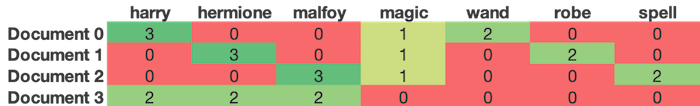

Then each topic has a probability associated with each word, and each topic has a probability associated per each document.

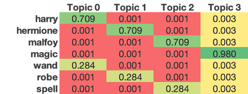

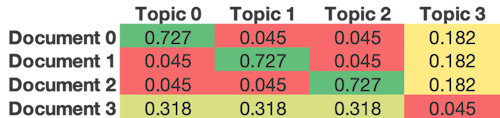

### Evaluating Topic Models

1. Perplexity: It measures the log-likelihood of a held-out test set. In other words, it estimates how a set of words not used for training, falls into the topic distribution inferred by LDA.
2. Coherence: given the n top words in a topic, it measures the pairwise likelihood of two words appearing in a document.

Perplexity is not correlated with human judgments (Newman et al, 2010)

### Further reading

Chang, J., Gerrish, S., Wang, C., Boyd-Graber, J. L., & Blei, D. M. (2009). Reading tea leaves: How humans interpret topic models. In Advances in neural information processing systems (pp. 288-296).

Blei, D. M., Ng, A. Y., & Jordan, M. I. (2003). Latent dirichlet allocation. Journal of machine Learning research, 3(Jan), 993-1022.

Newman, D., Lau, J. H., Grieser, K., & Baldwin, T. (2010, June). Automatic evaluation of topic coherence. In Human Language Technologies: The 2010 Annual Conference of the North American Chapter of the Association for Computational Linguistics (pp. 100-108). Association for Computational Linguistics.

Continue to PTM in Python(part 1)